# Lab W3

COMP 061 - Programming for Data Science

Copyright © Dana Nehoran 2017

**Lab Week 3**

```python
# Preparation for pandas and NumPy
import numpy as np
import pandas as pd
from pandas import DataFrame, Series

# Set some pandas options
pd.set_option('display.notebook_repr_html', False)
pd.set_option('display.max_rows', 60)
pd.set_option('display.max_columns', 60)
pd.set_option('display.width', 1000)

# Preparation for matplotlib
%matplotlib inline
```

Sales and Rentals data: `Sales and Rentals.csv`

> **Question 1:** Data Exploration

> Practice for HW question 1

**a)** Read the data from the file `Sales and Rentals.csv` into a pandas dataframe and print it.

Your answer here

```python
my_dataframe = pd.read_csv("Sales and Rentals.csv")
```

```python
display(my_dataframe)
```

```
    id property_type  condition property_style  zipcode  property_size  bedroom  bath     price   lease
0    1         sales          0   multi-family    10001           1343        1   1.0  200000.0     NaN
1    2         sales          1      apartment    10002           4460        1   1.0  200000.0     NaN
2    3         sales          2          condo    10003           3742        1   1.0  200000.0     NaN
3    4         sales          3          condo    10004           3481        1   1.0  200000.0     NaN
4    5         sales          4       townhome    10005           4398        2   1.0  250000.0     NaN
5    6         sales          0  single-family    10006           2424        3   2.0  250000.0     NaN
6    7         sales          1       colonial    10007           1633        3   2.0  300000.0     NaN
7    8         sales          2       colonial    10008           1630        3   2.0  325000.0     NaN
8    9         sales          3       cape cod    10009           3767        3   2.0  350000.0     NaN
9   10         sales          4      classical    10010           4304        3   2.0  375000.0     NaN
10  11         sales          0       colonial    10011           3971        3   2.0  350000.0     NaN
11  12         sales          1       colonial    10012           3994        3   2.0  400000.0     NaN
12  13         sales          2       colonial    10013           3221        3   2.0  450000.0     NaN
13  14         sales          3     antebellum    10014           1019        3   2.0  450000.0     NaN
```

[output cut: 36 more lines]

**b)** Print all multi-family houses larger than 3,000 square foot

Your answer here

```python
my_dataframe[(my_dataframe["property_style"] == "multi-family") & (my_dataframe["property_size"]>3000)]
```

```
    id property_type  condition property_style  zipcode  property_size  bedroom  bath     price   lease
16  17         sales          1   multi-family    10018           3146        3   2.5  425000.0     NaN
17  18         sales          2   multi-family    10019           3425        3   2.5  450000.0     NaN
38  39       rentals          3   multi-family    10040           3380        3   2.0       NaN  2500.0
```

**c)** Print all Victoraian houses for lease

Your answer here

```python
my_dataframe[(my_dataframe["property_style"] == "victorian") & (my_dataframe["property_type"]== "rentals")]
```

```
    id property_type  condition property_style  zipcode  property_size  bedroom  bath  price   lease
32  33       rentals          2      victorian    10034           2983        3   2.0    NaN  2100.0
33  34       rentals          3      victorian    10035           1054        3   2.0    NaN  2200.0
35  36       rentals          0      victorian    10037           3324        3   2.0    NaN  2000.0
39  40       rentals          4      victorian    10041           1205        3   2.0    NaN  3000.0
41  42       rentals          1      victorian    10044           2565        3   2.0    NaN  3000.0
44  45       rentals          4      victorian    10055           3312        3   2.0    NaN  2000.0
45  46       rentals          0      victorian    10060           2465        3   2.0    NaN  2000.0
46  47       rentals          1      victorian    10060           2534        3   2.0    NaN  2000.0
47  48       rentals          2      victorian    10069           3316        3   2.0    NaN  2500.0
48  49       rentals          3      victorian    10072           4436        3   2.0    NaN  2500.0
```

**d) Segmentation of your own:** Create a segmentation of the data that prints 4 columns and not more than 8 rows using at least 3 columns for the condition

Your answer here

```python
my_dataframe[["property_type", "property_style", "property_size", "bedroom"]][(my_dataframe.property_style=="victorian")&
                                                    (my_dataframe.property_size < 2900)|
                                                    (my_dataframe.property_style == "multi-family")&
                                                    (my_dataframe.bedroom == 1)]
```

```
   property_type property_style  property_size  bedroom
0          sales   multi-family           1343        1
24         sales      victorian           1930        4
25       rentals   multi-family           1416        1
33       rentals      victorian           1054        3
39       rentals      victorian           1205        3
41       rentals      victorian           2565        3
45       rentals      victorian           2465        3
46       rentals      victorian           2534        3
```

**e)** Create a plot of your choice

Your answer here

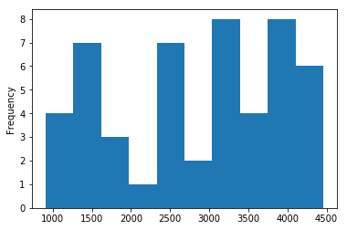

```python
my_dataframe.property_size.plot(kind="hist")
```

> **Question 2 :** pandas Conditionals

> Practice for HW question 2

**a) Comparing**: Create code that compares if there are more houses for rent or for sale

Your answer here

```python
sales_df = my_dataframe[my_dataframe.property_type == "Sales"]
rentals_df = my_dataframe[my_dataframe.property_type == "Rentals"]
TotalSales = sales_df.shape[0]
TotalRentals = rentals_df.shape[0]
if (TotalSales < TotalRentals):
    print("There are more houses for sale than for rent")
elif (TotalSales == TotalRentals):
    print("Both house for sales and renat are equal")
else:
    print("There are more houses for rent than for sale")
```

```
Both house for sales and renat are equal
```

**b) Colonial Houses**: A development company wants to analyze status of all colonial houses. If the maximum price of the colonial houses is more than \$550,000, the company will spend resources on their restoration. Write a code printing if the company should dedicate these resources or not.

Your answer here

```python
colonial_df = my_dataframe[my_dataframe.property_style == "colonial"]
max(colonial_df.price)
if (max(colonial_df.price) > 550000):
    print("Company will spend resources")
elif (colonial_df == 550000):
    print("?")
else:
    print("Company will not spend resources")
```

```
Company will spend resources
```

**c) Your own condition**: Write a condition of your own using 2 or 3 columns. Explain your results.

Your answer here

```python
quantity_price_greater_100000 = my_dataframe[my_dataframe.price > 100000].shape[0]
print(quantity_price_greater_100000)
```

```
25
```

```python
quantity_my_dataframe_greater_200000 = my_dataframe[my_dataframe.price > 200000].shape[1]
print(quantity_my_dataframe_greater_200000)
```

```
10
```

```python
if (quantity_price_greater_100000 > 50):
    print("We have more than 50 houses more expensive than $100000")
if (quantity_my_dataframe_greater_200000 > 20):
    print("We have more than 20 houses with sales greater than $200000")
```

> **Question 3:** Understanding Conditionals

> Practice for HW question 3

**a) Understanding Python**: Why does this code print the wrong arrival times for my cruise?

Write the code that corrects this.

```python
cruise_first_stop = "Port 1"
time = "9:00am"
cruise_second_stop = "Port 2"
time = "1:30am"
cruise_last_stop = "Port 3"
time = "7:45pm"


print ("First stop", cruise_first_stop, "time:", time)
print ("Second stop", cruise_second_stop, "time:", time)
print ("Third stop", cruise_last_stop, "time:", time)
```

```
First stop Port 1 time: 7:45pm
Second stop Port 2 time: 7:45pm
Third stop Port 3 time: 7:45pm
```

Your answer here

Because the variable "time" was assigned to multiple strings. It has to be its own variable for each time. If not the last input that you have for the variable "time" will be printed out.

Your possible solution here

```python
ruise_first_stop = "Port 1"
time1 = "9:00am"
cruise_second_stop = "Port 2"
time2 = "1:30am"
cruise_last_stop = "Port 3"
time3 = "7:45pm"

print ("First stop", cruise_first_stop, "time:", time1)
print ("Second stop",cruise_second_stop, "time:", time2)
print ("Third stop", cruise_last_stop, "time:", time3)
```

```
First stop Port 1 time: 9:00am
Second stop Port 2 time: 1:30am
Third stop Port 3 time: 7:45pm
```

**b) Understanding Conditionals**: Per our compay policy, we don't hire employees with criminal record.

The data looks like this:

```python
has_necessary_skills = True
has_good_references = True
has_criminal_record = True
```

Why does the code below not work properly and recommends to hire this person, even though he has a criminal record?

```python
if has_necessary_skills:
    if has_good_references:
        print ("Let's hire this person")
    if not has_criminal_record:
        print ("Let's hire this person")
```

```
Let's hire this person
```

Your answer here

There is no else statement in this conditional.

Your possible solution here

```python
if has_necessary_skills:
    if has_good_references:
        if has_criminal_record:
            print ("Do not hire this person")
        else:
            print("Hire")
    else:
        print("Do not hire this person")
else:
    print("Do not hire this person ")
```

```
Do not hire this person
```